# Obj1.2

Reilly Maw

6/7/2018

I would first load the data into R in order to explore/test the data.

```r
rm(list=ls())
data<-read.csv("jpmc_rse_assignment_data.csv",sep=",",header=T)
dim(data)
```

```
## [1] 27261    75
```

Three feasible issues include

1. Unreliable, incorrect, or impossible entries.
2. Seeing how many NA answers were given since some variables such as ER34209 and ER34210 have options to not answer. This will require compiling a list of variables that have this “opt-out” option and testing the percentage of data points that responded in this way. If the percentage is high, that could raise questions about the integrity/projectability of the data.
2. Check the file for entries tagged as “possible listing error” if the number is high enough, then it could suggest that the data was disturbed in some way. This would again require going through every variable and seeing where this terminology arises.
3. Checking for age outliers is important to verify that the data wasn’t entered incorrectly. It is very unlikely that 0-5 or 105+ year old’s are taking the survey. This option is very quick and easy. There are almost no costs associated and the benefit is that the survey can be trusted in the most rudimentary capacity.

```r
### Test option iii)
# ER34104 is the age of the individual as of the 2011 interview, ER34204 is the age of
# individual as of the 2013 interview

age_11 <- data[7]
age_13 <- data[67]
summary(age_11)
```

```
##     ER34104
##  Min.   :   0.00
##  1st Qu.:  10.00
##  Median :  27.00
##  Mean   :  29.57
##  3rd Qu.:  46.00
##  Max.   :1004.00
```

```r
summary(age_13)
```

```
##     ER34204
##  Min.   :  0.00
##  1st Qu.: 10.00
##  Median : 27.00
##  Mean   : 29.66
##  3rd Qu.: 46.00
##  Max.   :999.00
```

```r
# One interesting find here is that in 2011 an individual was entered as 1,004 years old,
# which is obviously a mistake. This data point should probably be removed. It does prove
# that the document is not absent of data  entry issues.

# In the survey, 999 (refusal, NA, DK) and 0 (Inap.) represents an unknown age. So we will
# remove these entries.
clean_11 <- as.data.frame(age_11[! age_11$ER34104 %in% c(0,999,1004), ])
clean_13 <- as.data.frame(age_13[! age_13$ER34204 %in% c(0,999), ])

# 1stQ = 14, Median = 29, Mean = 32.15, 3rdQ = 48
summary(clean_11)
```

```
##  age_11[!age_11$ER34104 %in% c(0, 999, 1004), ]
##  Min.   :  1.00
##  1st Qu.: 14.00
##  Median : 29.00
##  Mean   : 32.15
##  3rd Qu.: 48.00
##  Max.   :100.00
```

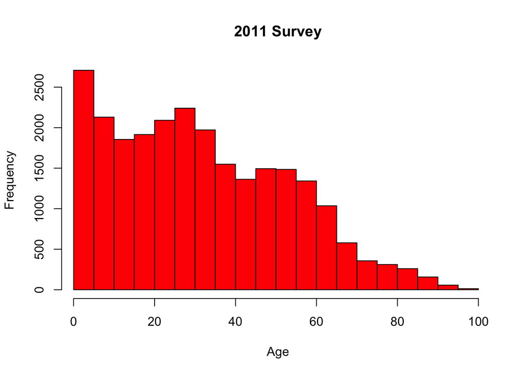

```r
hist(clean_11[,1],col="red",freq=T,xlim=c(1,100),main ='2011 Survey', xlab = "Age")
```

```r
# 1stQ = 14, Median = 29, Mean = 32.17, 3rdQ = 49
summary(clean_13)
```

```
##  age_13[!age_13$ER34204 %in% c(0, 999), ]
##  Min.   :  1.00
##  1st Qu.: 14.00
##  Median : 29.00
##  Mean   : 32.17
##  3rd Qu.: 49.00
##  Max.   :100.00
```

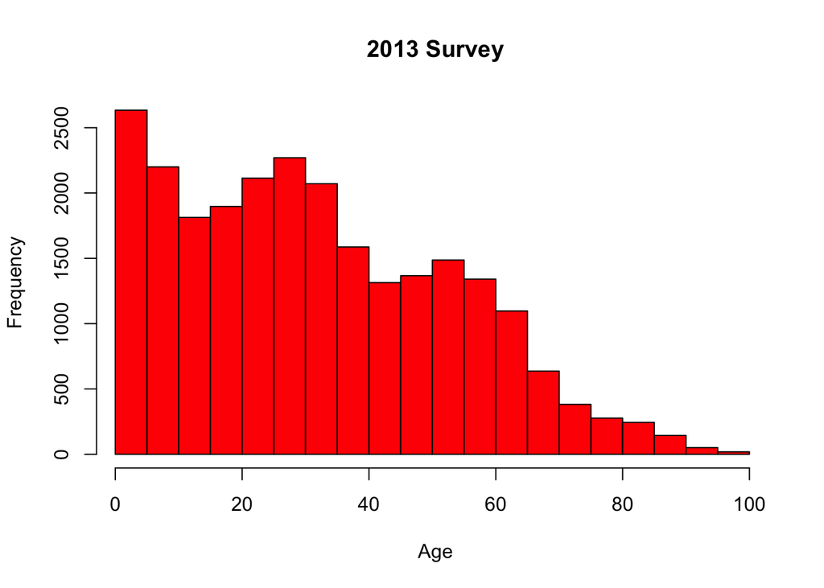

```r
hist(clean_13[,1],col="red",freq=T,xlim=c(1,100),main ='2013 Survey', xlab = "Age")
```